# Diseños factoriales

Kevin Palomino

2024-05-06

En las anteriores semanasse estudiaron los diseños en bloques donde sólo se tiene un factor de tratamientos, y el resto son factores de bloques que tienen una importancia secundaria en la investigación experimental. El objetivo de un diseño factorial es estudiar el efecto de varios factores sobre una o varias respuestas, cuando se tiene el mismo interés sobre todos los factores. Por ejemplo, uno de los objetivos particulares más importantes que frecuentemente tiene un diseño factorial es determinar una combinación de niveles de los factores en la que el desempeño del proceso sea mejor. Los factores pueden ser de tipo cualitativo (máquinas, tipos de material, operador, la presencia o ausencia de una operación previa), o de tipo cuantitativo (temperatura, humedad, velocidad, presión, la cantidad de un cierto material, etc.). Para estudiar la manera en la que influye cada factor sobre la variable de respuesta, es necesario elegir al menos dos niveles de prueba para cada uno de ellos. Con el diseño factorial completo se corren aleatoriamente todas las posibles combinaciones que pueden formarse con los niveles de los factores a investigar.

**Conceptos básicos**

- Factores: Fenómenos que potencialmente causan variación y que se pueden fijar en un valor dado.
- Niveles: Valores que un factor puede tomar.
- Tratamieto: Combinación de niveles de todos los factores involucrados en el experimento.
- Variable de respuesta: Se mide el efecto del factor sobre una variable dependiente.
- Experimento balanceado: Experimento en que todos los niveles aparecen el mismo número de veces.
- Efecto principal: Impacto en la respuesta por el cambio en un factor determinado a través de sus diferentes niveles.
- Efecto de interracción: Impacto en la respuesta por el cambio de un factor influido por la presencia de otro.

**Generalidades del DOE factorial**

La matriz de diseño o arreglo factorial es el conjunto de puntos experimentales o tratamientos que pueden formarse considerando todas las posibles combinaciones de los niveles de los factores. Para afinar ideas, si se sigue teniendo dos factores pero ahora uno tiene tres niveles y el otro dos, se pueden construir 3 × 2 combinaciones que dan lugar al diseño factorial 3 × 2. Observe que en el nombre del diseño factorial va implícito el número de tratamientos que lo componen. Para obtener el número de corridas experimentales se multiplica el número de tratamientos por el número de réplicas, donde una de éstas se lleva a cabo cada vez que se corre el arreglo completo. En general, la familia de diseños factoriales $2^k$ consiste en k factores, todos con dos niveles de prueba (los factoriales 2k se estudian con detalle en la siguiente semana); y la familia de diseños factoriales $3^k$ consiste en k factores, cada uno con tres niveles de prueba. Es claro que si los k factores no tienen la misma cantidad de niveles, debe escribirse el producto de manera explícita; por ejemplo, con k = 3 factores, el primero con cuatro niveles y los dos restantes con dos niveles, se tiene el diseño factorial 4 × 2 × 2.

**Efecto Principal y de interacción**

El efecto de un factor se define como el cambio observado en la variable de respuesta debido a un cambio de nivel de tal factor. En particular, los efectos principales son los cambios en la media de la variable de respuesta que se deben a la acción individual de cada factor. En términos matemáticos, el efecto principal de un factor con dos niveles es la diferencia entre la respuesta media observada cuando tal factor estuvo en su nivel alto, y la respuesta media observada cuando el factor estuvo en su nivel bajo. Por ejemplo, para los datos de la siguiente tabla, los efectos principales están dados por:

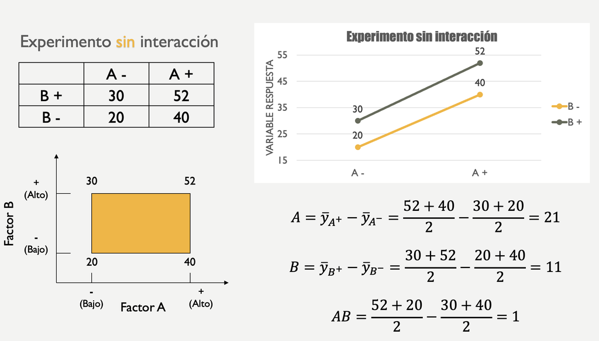

Ahora, para el caso donde si haya interacción:

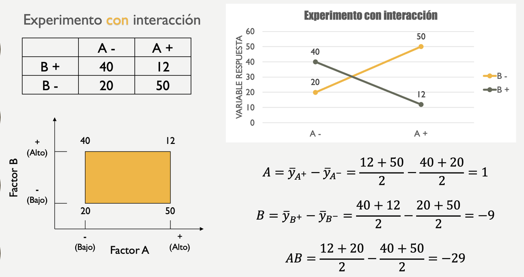

# Análisis de varianza (ANOVA)

El análisis de varianza (ANOVA) es una técnica estadística comúnmente utilizada en experimentos factoriales para determinar si existen diferencias significativas entre los niveles del dos o mas factor de interés en términos de su efecto sobre la variable dependiente. El ANOVA descompone la variabilidad total observada en el conjunto de datos en componentes atribuibles a diferentes fuentes de variación, como el efecto de los factores y la interacción.

**Objetivo:**

- Determinar con precisión el efecto de los factores de interés sobre la variable dependiente, mientras se controlan otras fuentes de variabilidad que podrían influir en los resultados.

**Componentes del ANOVA:**

- Factores: Variables independiente que se modifica en el experimento.
- Niveles: Categorías o valores específicos del factor.
- Variable de respuesta: Variable dependiente que se mide en el experimento.
- Modelo lineal: Se utiliza para describir la relación entre el factor y las variables de respuesta.
- Suma de cuadrados total (SST): Es la variabilidad total en los datos y se calcula como la suma de las diferencias al cuadrado entre cada observación y la media general de todas las observaciones.
- Suma de cuadrados del factor ($SS_{factores}$): Representa la variabilidad entre los niveles de cada factor de interés y se calcula como la suma de las diferencias al cuadrado entre la media de cada nivel del factor y la media general de todos los datos, ponderada por el número de observaciones en cada nivel.
- Suma de cuadrados del interracion ($SS_{interracion}$): Representa la variabilidad adicional en los datos debida a las interacciones entre los factores. En un diseño factorial, las interacciones ocurren cuando los efectos de un factor sobre la variable dependiente varían dependiendo de los niveles de otro factor o de otros factores.
- Suma de cuadrados del error (SSE): Es la variabilidad dentro de los bloques y se calcula como la suma de las diferencias al cuadrado entre cada observación y la media de su respectivo bloque.
- Grados de libertad: Indica el número de valores independientes en cada conjunto de datos.
- Media cuadrática: Estima la varianza dentro y entre los grupos.
- Razón F: Se utiliza para comparar la varianza entre los grupos con la varianza dentro de los grupos.
- Valor p: Indica la probabilidad de obtener una razón F tan grande o más grande por casualidad.

**Interpretación de resultados:**

- Si el valor p es menor que el nivel de significancia ($p < \alpha$), entonces se rechaza la hipótesis nula. Esto sugiere que las diferencias observadas entre los grupos son estadísticamente significativas, lo que indica que al menos uno de los grupos difiere significativamente de los demás.
- Si el valor p es mayor que el nivel de significancia ($p ≥ \alpha$), entonces no se rechaza la hipótesis nula. En este caso, no hay evidencia suficiente para concluir que existen diferencias significativas entre los grupos comparados.

**Tabla de datos**

En general, los datos para este doe tiene la siguiente forma:

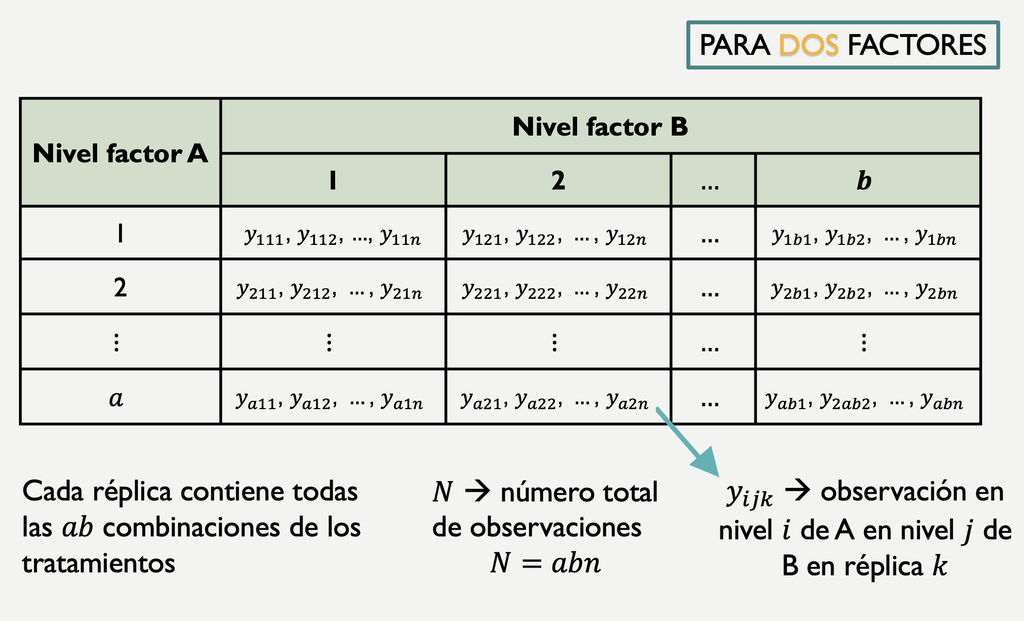

**Hipótesis**

Las hipótesis a probar para este DOE son las siguientes:

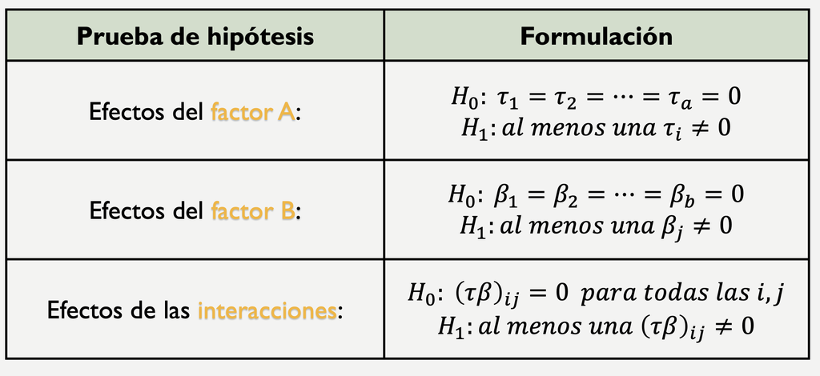

**Ecuaciones**

Es la suma total de cuadrados dada por:

$$SST=\sum_{i=1}^{a}\sum_{j=1}^{b}\sum_{k=1}^{n}y^2_{ijk}-\frac{y^2_{..}}{abn}$$

La suma cuadrada del efecto principal A esta expresada por:

$$SS_{A}=\frac{1}{bn}\sum_{i=1}^{a}y^2_{i..}-\frac{y^2_{...}}{abn}$$
La suma cuadrada del efecto principal B esta expresada por:

$$SS_{B}=\frac{1}{an}\sum_{j=1}^{b}y^2_{.j.}-\frac{y^2_{...}}{abn}$$

Ahora bien, para el caso del efecto de interacción, es conveniente obtener la
$$SS_{AB}$$
en dos etapas. Primero calculamos la suma de cuadrados entre los totales de las celdas $ab$, que se llama la suma de cuadrados debido a los “subtotales”:

$$SS_{SubTotal}=\frac{1}{n}\sum_{i=1}^{a}\sum_{j=1}^{b}y^2_{ij.}-\frac{y^2_{...}}{abn}$$
Entonces, esta suma de cuadrados también contiene $SS_A$ y $SS_B$. Por lo tanto, el segundo paso es calcular $SS_{AB}$ como:

$$SS_{AB}=SS_{SubTotal}-SS_{A}-SS_{B}$$

y finalmente,

$$SS_{E}=SST-SS_{AB}-SS_{A}-SS_{B}$$
O,

$$SS_{E}=SST-SS_{SubTotal}$$

Como hay un total de abn observaciones, la $SST$ tiene $abn – 1$ grados de libertad. Hay $a$ niveles del factor A de interés, así que $SS_{A}$ tiene $a – 1$ grados de libertad. Hay $b$ niveles del factor B de interés, así que $SS_{B}$ tiene $b – 1$ grados de libertad. Para el caso de $SS_{AB}$ se tiene que hay $(a-1)(b-1)$ grados de libertad, mientras que la $SS_E$ tiene $ab(n-1)$.

Por otra parte, las sumas de cuadrados divididas entre sus respectivos grados de libertad se llaman cuadrados medios, y es una estimación de la magnitud de su correspondiente fuente de variabilidad. Los cuatro que más interesan son el cuadrado medio de factor A, factor B, la interacción y el cuadrado medio del error, que se denotan por:

$$MS_{A}=\frac{SS_{A}}{a-1}$$
$$MS_{B}=\frac{SS_{B}}{b-1}$$
$$MS_{AB}=\frac{SS_{AB}}{(a-1)(b-1)}$$

y,

$$MS_{E}=\frac{SS_E}{ab(n-1)}$$

Con base a lo anterior se construye los estadísticos de prueba como sigue:

$$F_0=\frac{MS_{A}}{MS_E}$$

$$F_0=\frac{MS_{b}}{MS_E}$$
y,

$$F_0=\frac{MS_{AB}}{MS_E}$$

La tabla resumen de análisis de varianza (ANOVA) que se muestra en la siguiente tabla:

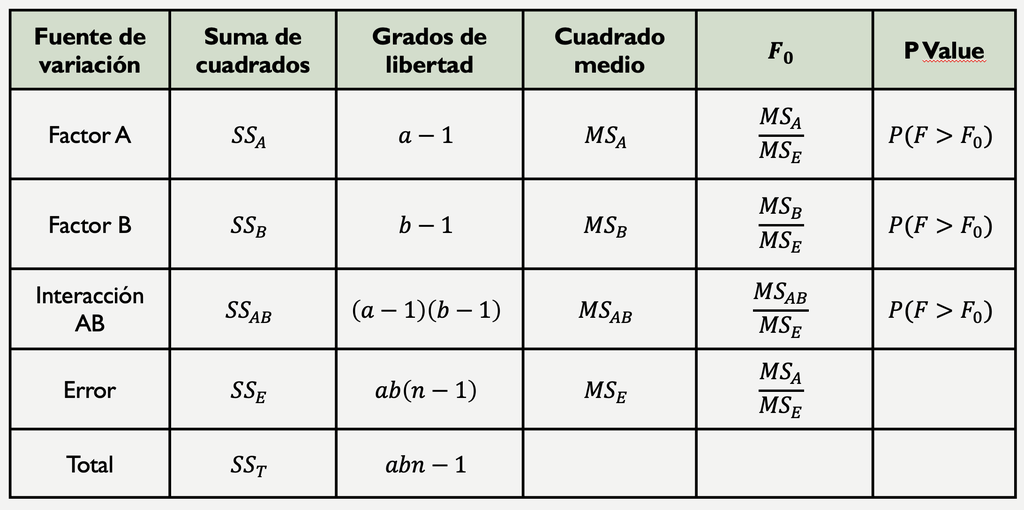

## Ejemplo 1

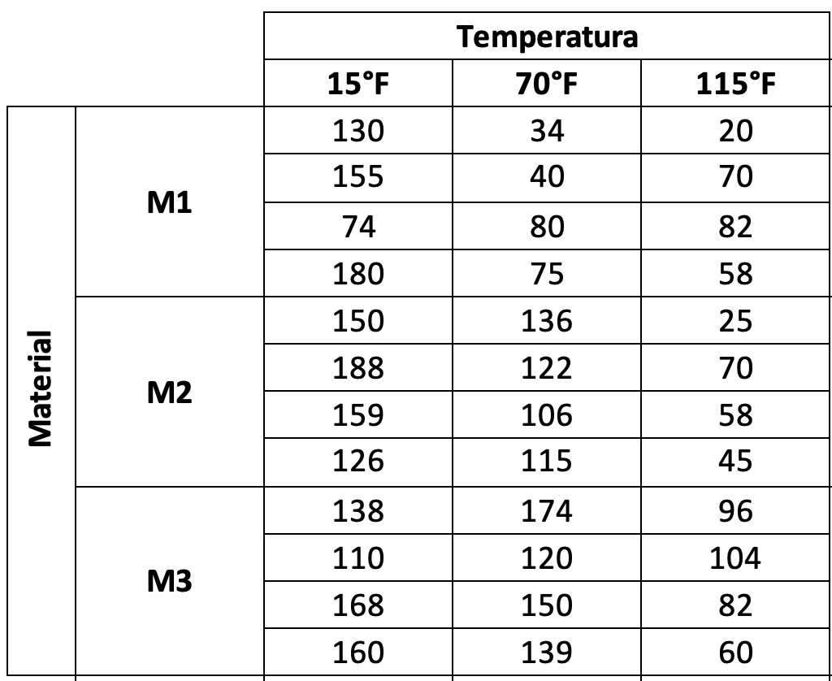

**Solución**

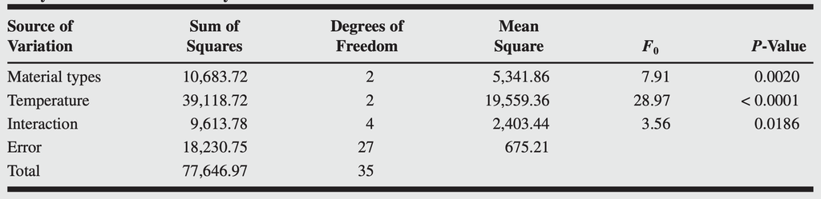

- **Usando R**

Incialmente, se construye el dataframe de los datos

```r
library(readxl)
datos <- read_excel("data/Datos_Codigo_factorial.xlsx")

datos$Material <- as.factor(datos$Material)
datos$Temperature <- as.factor(datos$Temperature)
#Mostramos la estructura de los datos
str(datos)
```

```
## tibble [36 × 3] (S3: tbl_df/tbl/data.frame)
##  $ Material   : Factor w/ 3 levels "M1","M2","M3": 1 1 1 1 2 2 2 2 3 3 ...
##  $ Temperature: Factor w/ 3 levels "15","70","115": 1 1 1 1 1 1 1 1 1 1 ...
##  $ Life       : num [1:36] 130 155 74 180 150 188 159 126 138 110 ...
```

```r
head(datos)
```

```
## # A tibble: 6 × 3
##   Material Temperature  Life
##   <fct>    <fct>       <dbl>
## 1 M1       15            130
## 2 M1       15            155
## 3 M1       15             74
## 4 M1       15            180
## 5 M2       15            150
## 6 M2       15            188
```

```r
# Cuantos datos hay?
NROW(datos)
```

```
## [1] 36
```

```r
## replicas por tratamientos
with(datos, tapply(Life, list(Material, Temperature), length))
```

```
##    15 70 115
## M1  4  4   4
## M2  4  4   4
## M3  4  4   4
```

Antes de iniciar la etapa de la construcción del anova, en R podemos revisar descriptivamente si hay una diferencia entre las medias de los niveles estudiantes y los bloques, esto es:

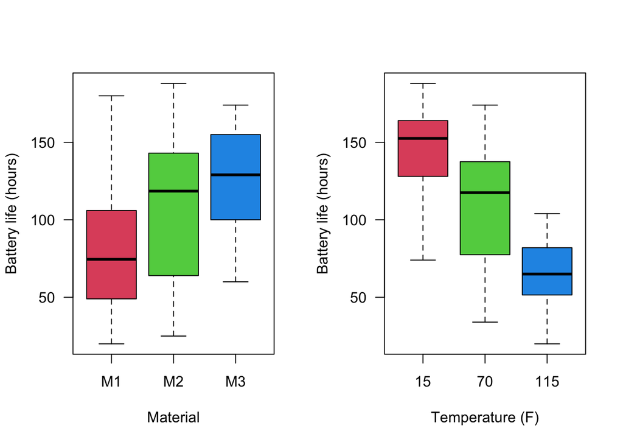

```r
## boxplots para revisar efectos

par(mfrow = c(1, 2))
boxplot(Life ~ Material, data = datos, las = 1, col = 2:4,
        xlab = 'Material', ylab = 'Battery life (hours)')
boxplot(Life ~ Temperature, data = datos, las = 1, col = 2:4,
        xlab = 'Temperature (F)', ylab = 'Battery life (hours)')
```

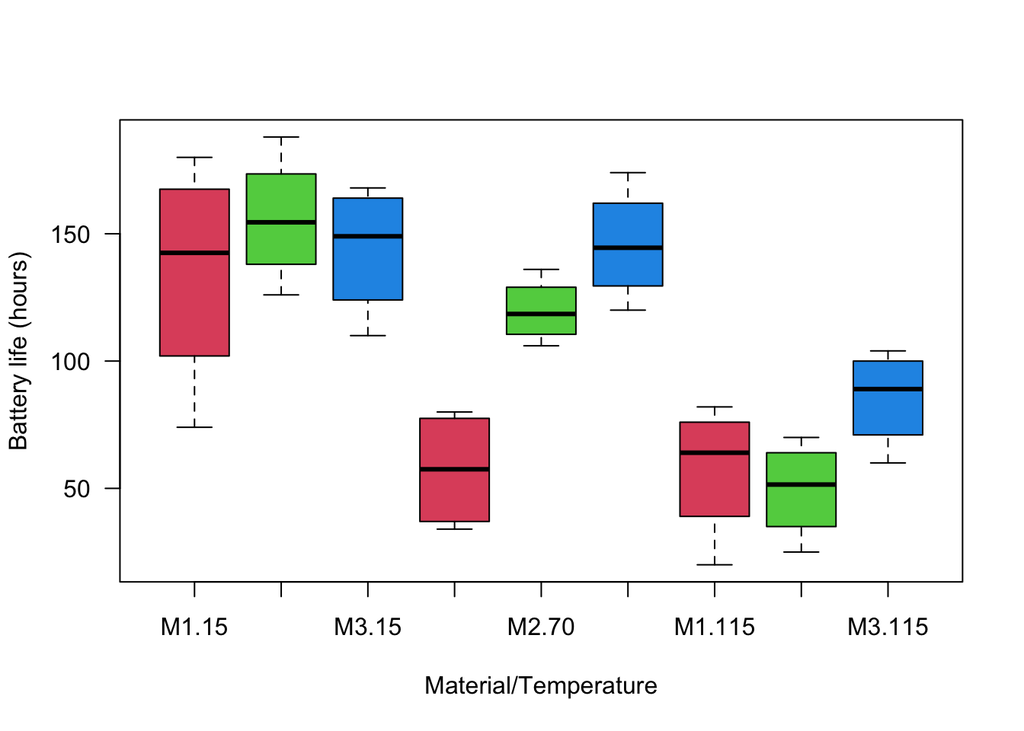

```r
## boxplot for interactions
par(mfrow = c(1, 1))
boxplot(Life ~ Material*Temperature,
        data = datos, las = 1, col = 2:4,
        xlab = 'Material/Temperature', ylab = 'Battery life (hours)')
```

Ahora veamos la interacciones:

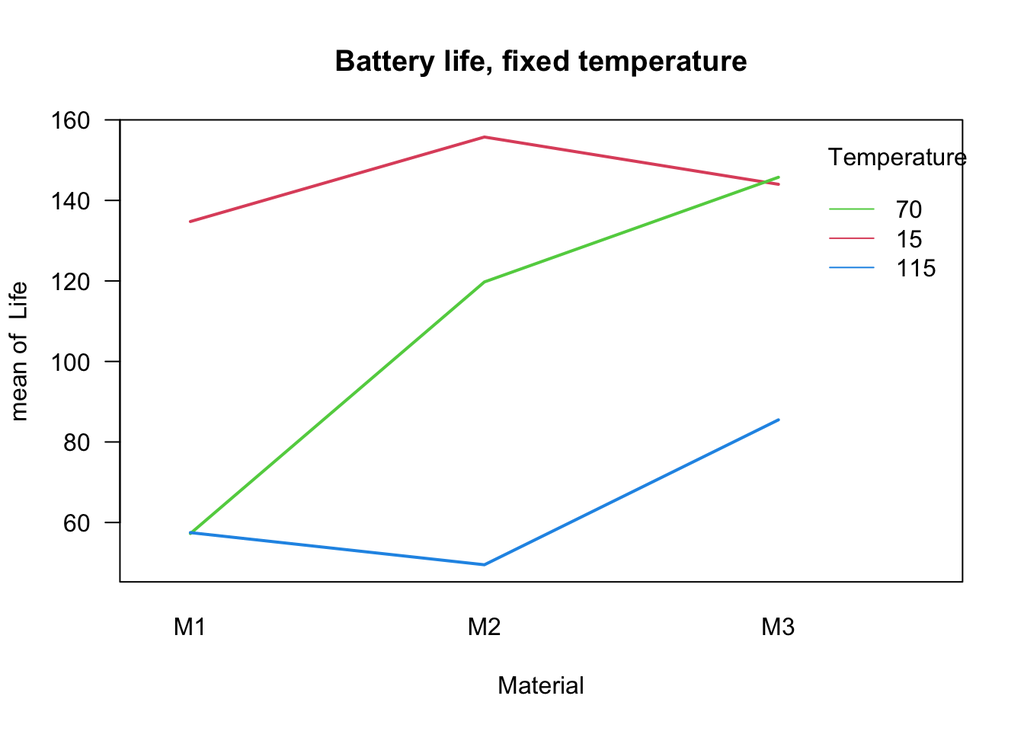

```r
## boxplots para revisar efectos

with(datos,
     interaction.plot(Material, Temperature, Life,
                      las = 1,
                      lty = 1,
                      lwd = 2,
                      col = 2:4,
                      main = "Battery life, fixed temperature")
)
```

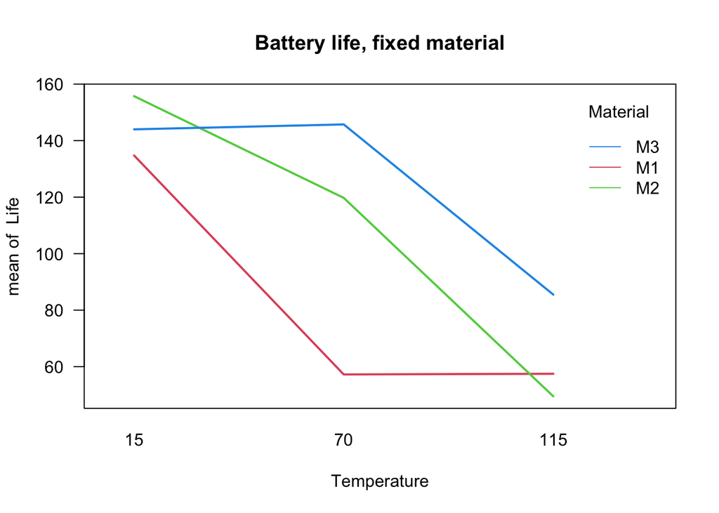

```r
## same fixing temperature
with(datos,
     interaction.plot(Temperature, Material, Life,
                      las = 1,
                      lty = 1,
                      lwd = 2,
                      col = 2:4,
                      main = "Battery life, fixed material")
)
```

Ahora, procedamos a calcular algunas medidas de tendencia central, posicion y dispersion:

```r
with(datos, tapply(Life, list(Material, Temperature), mean))
```

```
##        15     70  115
## M1 134.75  57.25 57.5
## M2 155.75 119.75 49.5
## M3 144.00 145.75 85.5
```

```r
with(datos, tapply(Life, list(Material, Temperature), sd))
```

```
##          15       70      115
## M1 45.35324 23.59908 26.85144
## M2 25.61738 12.65899 19.26136
## M3 25.97435 22.54440 19.27866
```

Ahora construimos la tabla ANOVA incluyendo el término de interacción:

```r
## ANOVA con la  interaccion
fit <- lm(Life ~ Material*Temperature, data = datos)
anova(fit)
```

```
## Analysis of Variance Table
##
## Response: Life
##                      Df Sum Sq Mean Sq F value    Pr(>F)
## Material              2  10684  5341.9  7.9114  0.001976 **
## Temperature           2  39119 19559.4 28.9677 1.909e-07 ***
## Material:Temperature  4   9614  2403.4  3.5595  0.018611 *
## Residuals            27  18231   675.2
## ---
## Signif. codes:  0 '***' 0.001 '**' 0.01 '*' 0.05 '.' 0.1 ' ' 1
```

```r
### Modelo de regression lineal
summary(fit)
```

```
##
## Call:
## lm(formula = Life ~ Material * Temperature, data = datos)
##
## Residuals:
##     Min      1Q  Median      3Q     Max
## -60.750 -14.625   1.375  17.937  45.250
##
## Coefficients:
##                           Estimate Std. Error t value Pr(>|t|)
## (Intercept)                 134.75      12.99  10.371 6.46e-11 ***
## MaterialM2                   21.00      18.37   1.143 0.263107
## MaterialM3                    9.25      18.37   0.503 0.618747
## Temperature70               -77.50      18.37  -4.218 0.000248 ***
## Temperature115              -77.25      18.37  -4.204 0.000257 ***
## MaterialM2:Temperature70     41.50      25.98   1.597 0.121886
## MaterialM3:Temperature70     79.25      25.98   3.050 0.005083 **
## MaterialM2:Temperature115   -29.00      25.98  -1.116 0.274242
## MaterialM3:Temperature115    18.75      25.98   0.722 0.476759
## ---
## Signif. codes:  0 '***' 0.001 '**' 0.01 '*' 0.05 '.' 0.1 ' ' 1
##
## Residual standard error: 25.98 on 27 degrees of freedom
## Multiple R-squared:  0.7652, Adjusted R-squared:  0.6956
## F-statistic:    11 on 8 and 27 DF,  p-value: 9.426e-07
```

La conclusión de este primer modelo es que la interacción entre temperature y material, definida como material:temperatura en el resultado de anova(fit), es no significativa al 1%.

Puesto que la interacción no es significativa, debemos remover este término del modelo y recalcularlo:

```r
## ANOVA sin interacciones
fit <- lm(Life ~ Material + Temperature, data = datos)
anova(fit)
```

```
## Analysis of Variance Table
##
## Response: Life
##             Df Sum Sq Mean Sq F value    Pr(>F)
## Material     2  10684  5341.9  5.9472  0.006515 **
## Temperature  2  39119 19559.4 21.7759 1.239e-06 ***
## Residuals   31  27845   898.2
## ---
## Signif. codes:  0 '***' 0.001 '**' 0.01 '*' 0.05 '.' 0.1 ' ' 1
```

La conclusion de la tabla ANOVA es que existe al menos un tipo de material para el que vida de las batería es diferente de la media global. Ademas, existe tambien un nivel de temperature para el cual el nivel de vida de las baterias difiere sustancialmente de la media global. En otras palabras, que ambos factores seleccionados influencian considerablemente la vida media de las baterias.